```python
import pandas as pd
import numpy as np
import matplotlib.pyplot as plt
import statsmodels.api as sm
import seaborn as sns
import scipy as sp
from statsmodels.stats.diagnostic import acorr_ljungbox
from statsmodels.graphics.tsaplots import plot_acf, plot_pacf
from statsmodels.tsa.stattools import adfuller
from statsmodels.graphics.tsaplots import plot_predict
from statsmodels.tsa.arima.model import ARIMA
from statsmodels.tsa.arima.model import ARIMAResults
from scipy.signal import detrend
```

```python
from google.colab import drive
drive.mount('/content/drive')
```

# Baggage claims for United Airlines

```python
# Load Data

data_path = '/content/drive/My Drive/Data/Baggage_United.csv'

bag_dat = pd.read_csv(data_path)

bag_dat.head
bag_dat.info()
print(bag_dat)
```

```
<class 'pandas.core.frame.DataFrame'>
RangeIndex: 84 entries, 0 to 83
Data columns (total 8 columns):
 #   Column     Non-Null Count  Dtype
---  ------     --------------  -----
 0   Airline    84 non-null     object
 1   Date       84 non-null     object
 2   Month      84 non-null     int64
 3   Year       84 non-null     int64
 4   Baggage    84 non-null     int64
 5   Scheduled  84 non-null     int64
 6   Cancelled  84 non-null     int64
 7   Enplaned   84 non-null     int64
dtypes: int64(6), object(2)
memory usage: 5.4+ KB
   Airline    Date  Month  Year  Baggage  Scheduled  Cancelled  Enplaned
0   United  Jan-04      1  2004    25015      45809       1017   4434315
1   United  Feb-04      2  2004    16660      42675        312   4458657
2   United  Mar-04      3  2004    19318      46512        321   5302929
3   United  Apr-04      4  2004    15638      45309        162   5288871
4   United  May-04      5  2004    19302      46630        652   5408451
..     ...     ...    ...   ...      ...        ...        ...       ...
79  United  Aug-10      8  2010    14099      30637        344   4263211
80  United  Sep-10      9  2010     9435      28072        161   3679517
81  United  Oct-10     10  2010     9565      29144        140   3952549
82  United  Nov-10     11  2010     8597      27318        104   3573268
83  United  Dec-10     12  2010    14415      27619        599   3493643

[84 rows x 8 columns]
```

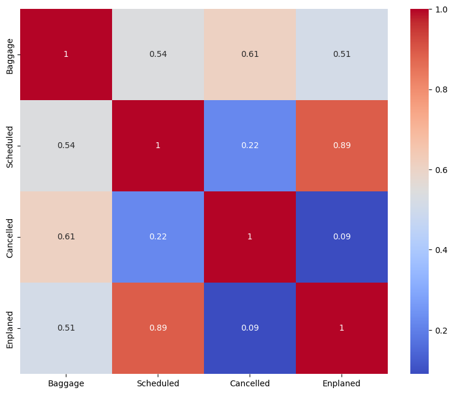

```python
bag_dat_sub = bag_dat.drop(columns=['Airline', 'Date', 'Month', 'Year'])


# Compute correlations
cormat = bag_dat_sub.corr()

# Round correlation matrix to 2 decimal places
cormat = cormat.round(2)

# Plot correlation matrix using a heatmap
plt.figure(figsize = (10,8))
sns.heatmap(cormat,annot=True, cmap = 'coolwarm')
plt.show()
```

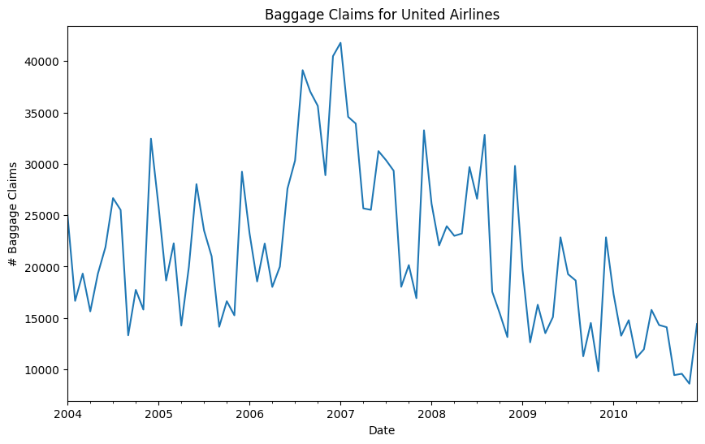

```python
# Convert date column to a date class variable

# Create a monthly index for the series
bag_dat['Date'] = pd.to_datetime(bag_dat['Date'], format="%b-%y")
bag_ts = pd.Series(bag_dat['Baggage'].values, index=bag_dat['Date'])

bag_ts.index.freq = 'MS'


#Plot the series
plt.figure(figsize=(10, 6))
bag_ts.plot()
plt.title("Baggage Claims for United Airlines")
plt.xlabel("Date")
plt.ylabel("# Baggage Claims")
plt.show()
```

```python
#execute the Ljung Box test on the Coffee series using 10 lags
Bags = bag_dat[['Baggage']]

sm.stats.acorr_ljungbox(Bags, lags=[10], return_df=True)
```

|  | lb_stat | lb_pvalue |
| --- | --- | --- |
| 10 | 160.317171 | 2.786746e-29 |

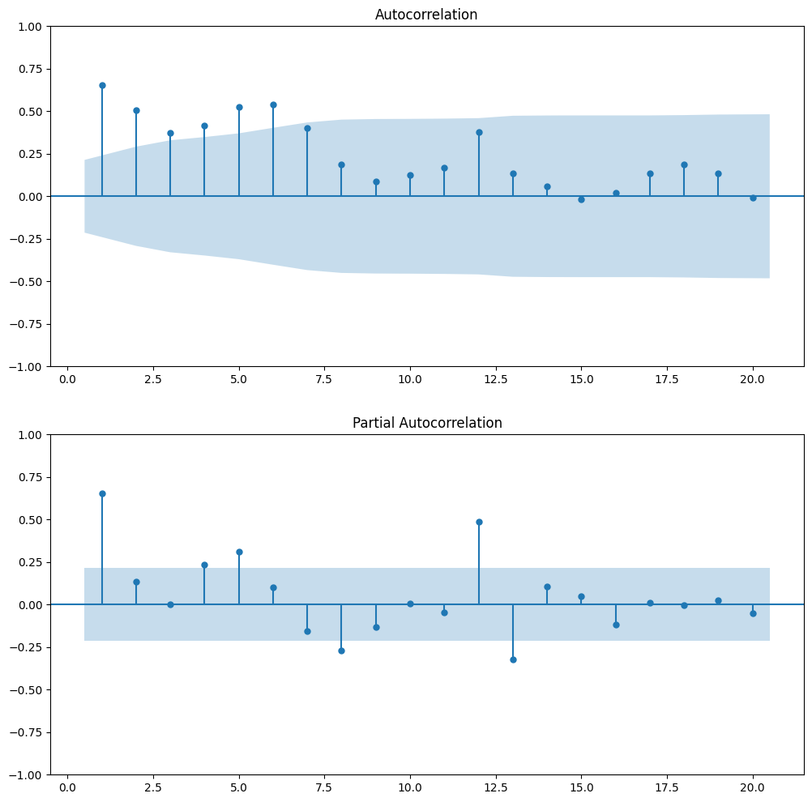

```python
#Plot the ACF and PACF

fig, (ax1, ax2) = plt.subplots(2, 1, figsize=(12, 12))
plot_acf(bag_ts, ax=ax1, zero=False)
plot_pacf(bag_ts, ax=ax2, zero=False)
plt.show()
```

For seasonal time series, the first step in the process is taking a seasonal difference. To do this, you need to include the seasonal_order(P,D,Q,s) option when you run the ARIMA procedure. P is the number of seasonal AR terms, Q is the number of seasonal MA terms, s is the length of the seasonal period (for example, s=12 if it takes 12 months to complete the seasonal cycle). To take a seasonal difference set D=1.

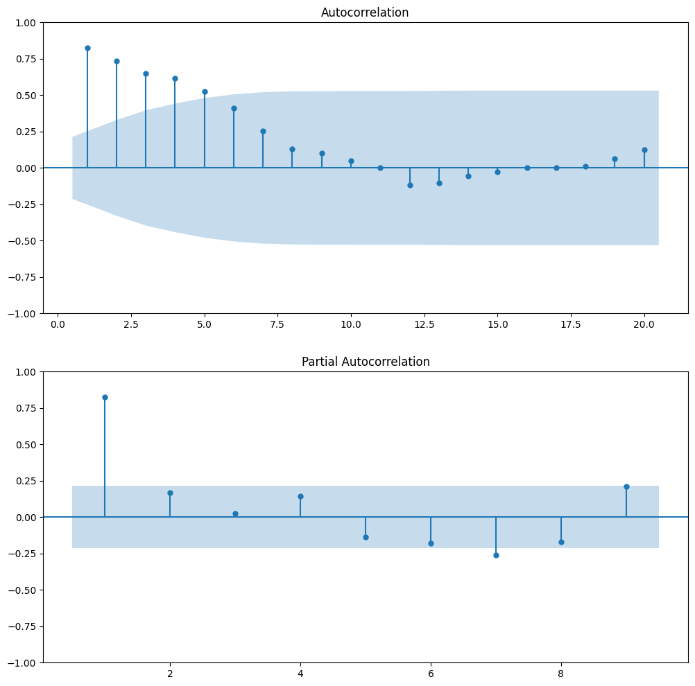

```python
# Fit ARIMA(0,0,0)x(0,1,0)[12] model to the data - This is simply taking the 12-month seasonal difference
#  which is yt - y(t-12)

fit_ARD12 = ARIMA(bag_ts, order=(0,0,0), seasonal_order=(0, 1, 0, 12)).fit()

# Plot ACF and PACF for residuals from the seasonal difference in order to
# assess the correlation still remaining in the data

residuals12 = fit_ARD12.resid

fig, (ax1, ax2) = plt.subplots(2, 1, figsize=(12, 12))
plot_acf(residuals12, ax=ax1, zero=False)
plot_pacf(residuals12, ax=ax2, zero=False, lags=9)
plt.show()
```

-- Notice that the ACF and PACF for the residuals look like a typical autoregressive signature, so the next step might be to add p = 1 to include an AR(1) term in the model. This will not be sufficient to get the residuals to white noise. Recall that an MA term can help to smooth out a model after differencing. In this case we took a seasonal difference, so we'll include a seasonal MA term by setting Q=1 in the seasonal order.

-- From the SARIMAX Results, we can see that the p-value of all the terms is less than 0.05, which means these terms are significant.

```
                                     SARIMAX Results
==========================================================================================
Dep. Variable:                                  y   No. Observations:                   84
Model:             ARIMA(1, 0, 0)x(0, 1, [1], 12)   Log Likelihood                -706.585
Date:                            Sun, 22 Oct 2023   AIC                           1419.170
Time:                                    23:26:39   BIC                           1426.000
Sample:                                01-01-2004   HQIC                          1421.890
                                     - 12-01-2010
Covariance Type:                              opg
==============================================================================
                 coef    std err          z      P>|z|      [0.025      0.975]
------------------------------------------------------------------------------
ar.L1          0.8258      0.035     23.635      0.000       0.757       0.894
ma.S.L12      -0.6496      0.116     -5.580      0.000      -0.878      -0.421
sigma2      1.813e+07   1.72e-09   1.05e+16      0.000    1.81e+07    1.81e+07
===================================================================================
Ljung-Box (L1) (Q):                   0.48   Jarque-Bera (JB):                17.36
Prob(Q):                              0.49   Prob(JB):                         0.00
Heteroskedasticity (H):               0.30   Skew:                            -0.47
Prob(H) (two-sided):                  0.00   Kurtosis:                         5.21
===================================================================================

Warnings:
[1] Covariance matrix calculated using the outer product of gradients (complex-step).
[2] Covariance matrix is singular or near-singular, with condition number 3.51e+31. Standard errors may be unstable.
```

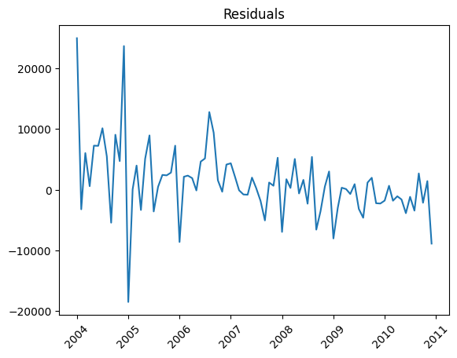

```
<statsmodels.tsa.statespace.mlemodel.PredictionResultsWrapper object at 0x7eb9e606bf70>
```

```python
# Fit ARIMA(1,0,0)x(0,1,1)[12] model to the data

#Best model for Baggage Complaints for United is ARIMA(1,0,0)x(0,1,1)[12]
fit_AR1 = ARIMA(bag_ts, order=(1,0,0), seasonal_order=(0, 1, 1, 12)).fit()


# Summary of the ARIMA model
print(fit_AR1.summary())

# Examine residuals from the model
residuals = fit_AR1.resid
plt.plot(residuals)
plt.title('Residuals')
plt.xticks(rotation=45)
plt.show()

#Generate the predicted values for the series
pred_units = fit_AR1.get_prediction()
print(pred_units)
```

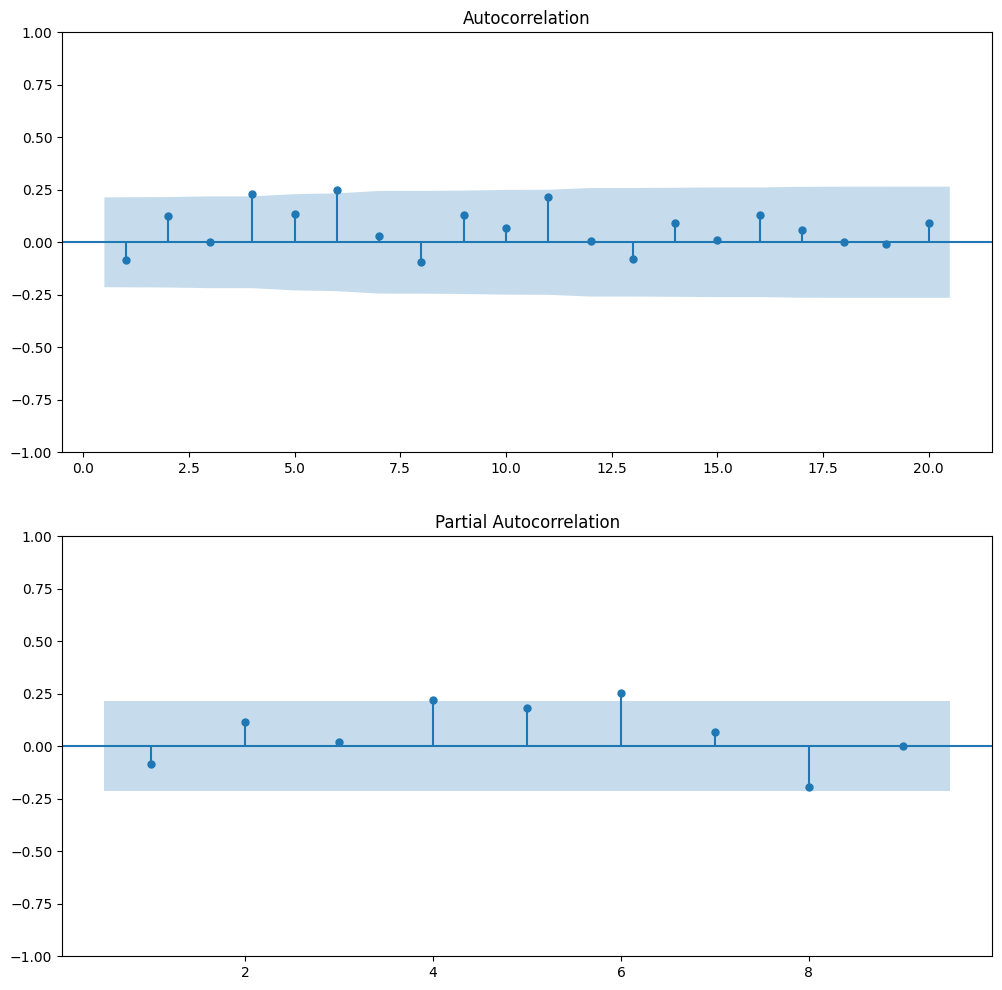

```python
# Plot ACF and PACF for residuals

fig, (ax1, ax2) = plt.subplots(2, 1, figsize=(12, 12))
plot_acf(residuals, ax=ax1, zero=False)
plot_pacf(residuals, ax=ax2, zero=False, lags=9)
plt.show()
```

After reviewing the ACF and PACF for the resiuals from this model and noticing that the Ljung Box test (below) indicates that the residuals are white noise,p-value = 0.075 > 0.05, this seems to be a reasonable model for the data.

```python
#execute the Ljung Box test on the residuals

sm.stats.acorr_ljungbox(residuals, lags=[10], return_df=True)
```

|  | lb_stat | lb_pvalue |
| --- | --- | --- |
| 10 | 16.951913 | 0.075435 |

Convert predictions into a data frame in order to compute the forecast error

```python
# convert to data frame
predicted_mean = pred_units.predicted_mean
conf_int = pred_units.conf_int()

prediction_df = pd.DataFrame({
    'predicted_mean': predicted_mean,
    'lower_bound': conf_int.iloc[:, 0],
    'upper_bound': conf_int.iloc[:, 1]
})
prediction_df = prediction_df.tail(-1)
prediction_df.head()
```

| Date | predicted_mean | lower_bound | upper_bound |
| --- | --- | --- | --- |
| 2004-02-01 | 19898.744014 | 9639.203017 | 30158.285011 |
| 2004-03-01 | 13278.758482 | 3019.242911 | 23538.274052 |
| 2004-04-01 | 15061.243589 | 4805.267095 | 25317.220083 |
| 2004-05-01 | 12035.958696 | 1785.483779 | 22286.433612 |
| 2004-06-01 | 14649.272687 | 4406.927829 | 24891.617545 |

Join actual values to predicted values

```python
# add back actuals --
prediction_df = pd.concat([prediction_df,bag_ts.to_frame(name='Baggage')],axis=1)
prediction_df = prediction_df.tail(-1)
prediction_df.head()
```

| Date | predicted_mean | lower_bound | upper_bound | Baggage |
| --- | --- | --- | --- | --- |
| 2004-02-01 | 19898.744014 | 9639.203017 | 30158.285011 | 16660 |
| 2004-03-01 | 13278.758482 | 3019.242911 | 23538.274052 | 19318 |
| 2004-04-01 | 15061.243589 | 4805.267095 | 25317.220083 | 15638 |
| 2004-05-01 | 12035.958696 | 1785.483779 | 22286.433612 | 19302 |
| 2004-06-01 | 14649.272687 | 4406.927829 | 24891.617545 | 21892 |

Calculate the Forecast Error

```python
# calc error
errors = prediction_df['Baggage'] - prediction_df['predicted_mean']
# absolue value of error
errors_abs = errors.abs()
# -- mape --
mape = (errors_abs/prediction_df['Baggage'].abs()).mean()
# -- rmse
rmse = (errors**2).mean()**0.5
# -- print it out
print(f'MAPE = {mape:.3%}')
print(f'RMSE = {rmse:,.3f}')
```

```
MAPE = 17.942%
RMSE = 5,462.825
```

Generate the forecast for the next six months

```python
# Generate forecast for the next six months
forecast = fit_AR1.get_forecast(steps=6)
mean_forecast = forecast.predicted_mean
confidence_intervals = forecast.conf_int()

# Create a DataFrame with forecasted values and confidence intervals
forecast_df = pd.DataFrame({
    'Forecasted_CPI': mean_forecast,
    'Lower_Bound': confidence_intervals.iloc[:, 0],
    'Upper_Bound': confidence_intervals.iloc[:, 1]
})

forecast_df
```

|  | Forecasted_CPI | Lower_Bound | Upper_Bound |
| --- | --- | --- | --- |
| 2011-01-01 | 11517.989987 | 3166.755574 | 19869.224401 |
| 2011-02-01 | 8070.936387 | -2757.702057 | 18899.574831 |
| 2011-03-01 | 11672.924016 | -560.511295 | 23906.359327 |
| 2011-04-01 | 9262.037189 | -3843.209135 | 22367.283512 |
| 2011-05-01 | 11463.779642 | -2204.058916 | 25131.618201 |
| 2011-06-01 | 17903.990424 | 3865.490787 | 31942.490060 |

Plot the series and append the six month forecast. Notice that the forecast follows a pattern similar to the one observed in the actual data

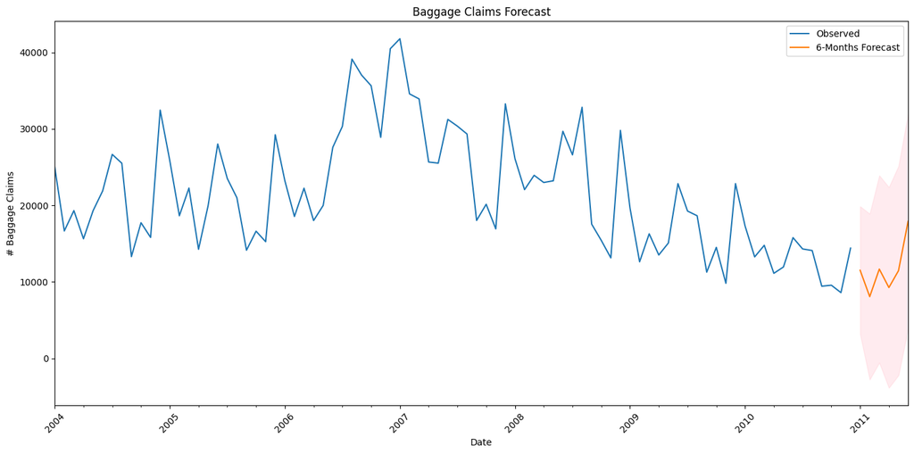

```python
# Plot forecast
plt.figure(figsize=(14, 7))
bag_ts.plot(label='Observed', legend=True)
mean_forecast.plot(label='6-Months Forecast', legend=True)
plt.fill_between(confidence_intervals.index,
                 confidence_intervals.iloc[:, 0],
                 confidence_intervals.iloc[:, 1], color='pink', alpha=0.3)
plt.title("Baggage Claims Forecast")
plt.xlabel("Date")
plt.ylabel("# Baggage Claims")
plt.xticks(rotation=45)
plt.tight_layout()
plt.legend()
plt.show()
```

# Cancelled flights for United Airlines

```python
# Load Data

data_path = '/content/drive/My Drive/Data/Baggage_United.csv'

bag_dat = pd.read_csv(data_path)

bag_dat.head
bag_dat.info()
print(bag_dat)
```

```
<class 'pandas.core.frame.DataFrame'>
RangeIndex: 84 entries, 0 to 83
Data columns (total 8 columns):
 #   Column     Non-Null Count  Dtype
---  ------     --------------  -----
 0   Airline    84 non-null     object
 1   Date       84 non-null     object
 2   Month      84 non-null     int64
 3   Year       84 non-null     int64
 4   Baggage    84 non-null     int64
 5   Scheduled  84 non-null     int64
 6   Cancelled  84 non-null     int64
 7   Enplaned   84 non-null     int64
dtypes: int64(6), object(2)
memory usage: 5.4+ KB
   Airline    Date  Month  Year  Baggage  Scheduled  Cancelled  Enplaned
0   United  Jan-04      1  2004    25015      45809       1017   4434315
1   United  Feb-04      2  2004    16660      42675        312   4458657
2   United  Mar-04      3  2004    19318      46512        321   5302929
3   United  Apr-04      4  2004    15638      45309        162   5288871
4   United  May-04      5  2004    19302      46630        652   5408451
..     ...     ...    ...   ...      ...        ...        ...       ...
79  United  Aug-10      8  2010    14099      30637        344   4263211
80  United  Sep-10      9  2010     9435      28072        161   3679517
81  United  Oct-10     10  2010     9565      29144        140   3952549
82  United  Nov-10     11  2010     8597      27318        104   3573268
83  United  Dec-10     12  2010    14415      27619        599   3493643

[84 rows x 8 columns]
```

## Examine the correlation between the number of baggage claims and the number of canceled flights, passengers enplaned, and flights scheduled.

- From the correlation table we can see the correlation between baggage claims and Cancelled Flights (Correlation: 0.61):There is a moderate positive correlation between the number of canceled flights and the number of baggage claims. This suggests that when airlines experience more flight cancellations, there is a tendency for an increase in baggage claims. Possible explanations could include disruptions in travel plans leading to mishandled baggage or re-routing of luggage causing delays and issues.
- The correlation between baggage claims and Scheduled Flights (Correlation: 0.54): A correlation of 0.54 signifies a moderate positive relationship. The positive sign indicates that as the number of scheduled flights increases, the number of baggage claims also tends to increase. An increase in scheduled flights could mean more passengers, leading to more baggage being handled and, consequently, more baggage claims.
- The correlation between baggage claims and Enplaned Passengers (Correlation: 0.51): A moderate positive relationship. The positive sign indicates that as the number of enplaned passengers increases, the number of baggage claims also tends to increase. Airlines with higher passenger numbers might experience a proportional increase in both enplaned passengers and baggage claims.

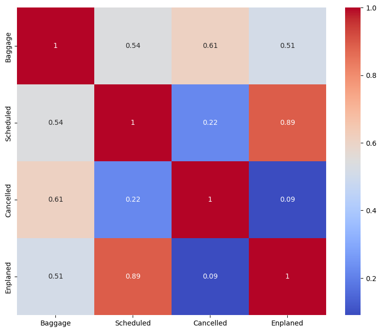

```python
bag_dat_sub = bag_dat.drop(columns=['Airline', 'Date', 'Month', 'Year'])


# Compute correlations
cormat = bag_dat_sub.corr()

# Round correlation matrix to 2 decimal places
cormat = cormat.round(2)

# Plot correlation matrix using a heatmap
plt.figure(figsize = (10,8))
sns.heatmap(cormat,annot=True, cmap = 'coolwarm')
plt.show()
```

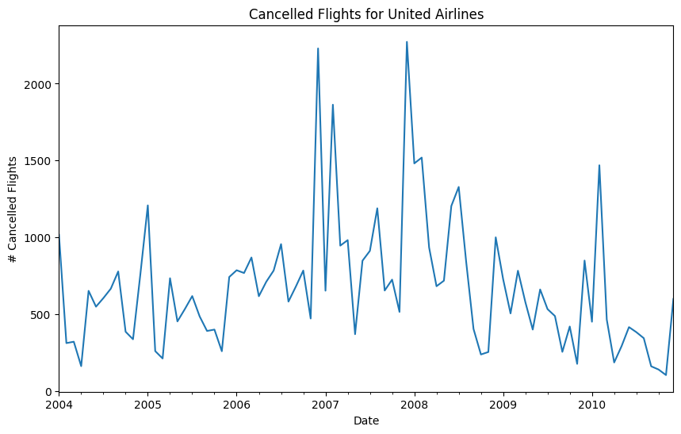

```python
# Convert date column to a date class variable

# Create a monthly index for the series
bag_dat['Date'] = pd.to_datetime(bag_dat['Date'], format="%b-%y")
bag_ts = pd.Series(bag_dat['Cancelled'].values, index=bag_dat['Date'])

bag_ts.index.freq = 'MS'


#Plot the series
plt.figure(figsize=(10, 6))
bag_ts.plot()
plt.title("Cancelled Flights for United Airlines")
plt.xlabel("Date")
plt.ylabel("# Cancelled Flights")
plt.show()
```

```python
#execute the Ljung Box test on the Cancelled series using 12 lags
Bags = bag_dat[['Cancelled']]

sm.stats.acorr_ljungbox(Bags, lags=[12], return_df=True)
```

|  | lb_stat | lb_pvalue |
| --- | --- | --- |
| 12 | 58.312388 | 4.575242e-08 |

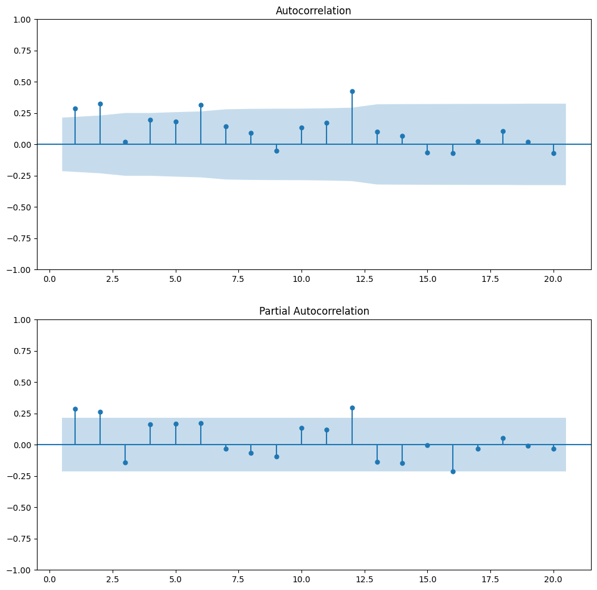

```python
#Plot the ACF and PACF for the Cancelled series

fig, (ax1, ax2) = plt.subplots(2, 1, figsize=(12, 12))
plot_acf(bag_ts, ax=ax1, zero=False)
plot_pacf(bag_ts, ax=ax2, zero=False)
plt.show()
```

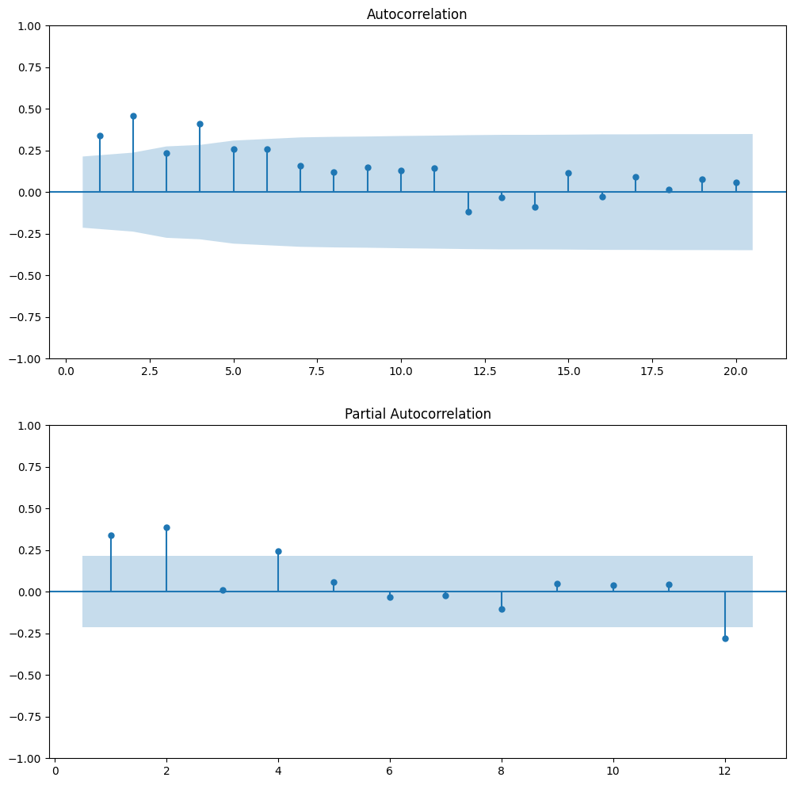

```python
# Fit ARIMA(0,0,0)x(0,1,0)[12] model to the data - This is simply taking the 12-month seasonal difference
#  which is yt - y(t-12)

fit_ARD12 = ARIMA(bag_ts, order=(0,0,0), seasonal_order=(0, 1, 0, 12)).fit()

# Plot ACF and PACF for residuals from the seasonal difference in order to
# assess the correlation still remaining in the data

residuals12 = fit_ARD12.resid

fig, (ax1, ax2) = plt.subplots(2, 1, figsize=(12, 12))
plot_acf(residuals12, ax=ax1, zero=False)
plot_pacf(residuals12, ax=ax2, zero=False, lags=12)
plt.show()
```

```python
#Dickey Fuller (single mean version)
adfuller(bag_ts, regression='n')
```

```
(-0.46845695519115005,
 0.509042041166262,
 11,
 72,
 {'1%': -2.5974924305555556,
  '5%': -1.9452960160536694,
  '10%': -1.6135866902434841},
 1055.7656257235892)
```

- From the SARIMAX Results, we can see that the p-value of all the terms is less than 0.05, which means these terms are significant.

```
                                    SARIMAX Results
========================================================================================
Dep. Variable:                                y   No. Observations:                   84
Model:             ARIMA(0, 1, 1)x(0, 1, 1, 12)   Log Likelihood                -521.649
Date:                          Sun, 22 Oct 2023   AIC                           1049.299
Time:                                  23:26:49   BIC                           1056.087
Sample:                              01-01-2004   HQIC                          1051.998
                                   - 12-01-2010
Covariance Type:                            opg
==============================================================================
                 coef    std err          z      P>|z|      [0.025      0.975]
------------------------------------------------------------------------------
ma.L1         -0.7702      0.081     -9.519      0.000      -0.929      -0.612
ma.S.L12      -0.6762      0.150     -4.508      0.000      -0.970      -0.382
sigma2      1.281e+05    1.7e+04      7.519      0.000    9.47e+04    1.61e+05
===================================================================================
Ljung-Box (L1) (Q):                   1.46   Jarque-Bera (JB):                29.55
Prob(Q):                              0.23   Prob(JB):                         0.00
Heteroskedasticity (H):               0.51   Skew:                             1.02
Prob(H) (two-sided):                  0.11   Kurtosis:                         5.41
===================================================================================

Warnings:
[1] Covariance matrix calculated using the outer product of gradients (complex-step).
```

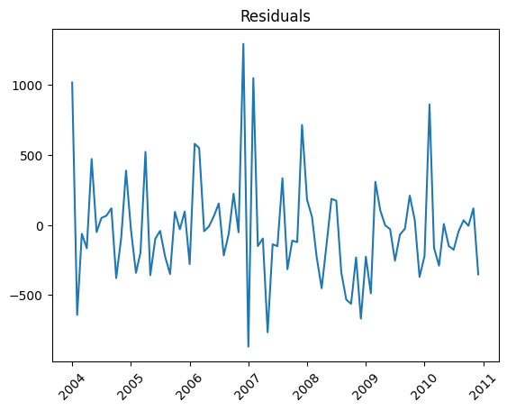

```
<statsmodels.tsa.statespace.mlemodel.PredictionResultsWrapper object at 0x7eb9e60d0e20>
```

```python
# Fit ARIMA(0,1,1)x(0,1,1)[12] model to the data

#Best model for cancelled for United is ARIMA(0,1,1)x(0,1,1)[12]
fit_AR1 = ARIMA(bag_ts, order=(0,1,1), seasonal_order=(0, 1, 1, 12)).fit()


# Summary of the ARIMA model
print(fit_AR1.summary())

# Examine residuals from the model
residuals = fit_AR1.resid
plt.plot(residuals)
plt.title('Residuals')
plt.xticks(rotation=45)
plt.show()

#Generate the predicted values for the series
pred_units = fit_AR1.get_prediction()
print(pred_units)
```

- From Plot ACF and PACF for residuals, we can not see any significantly outstanding there

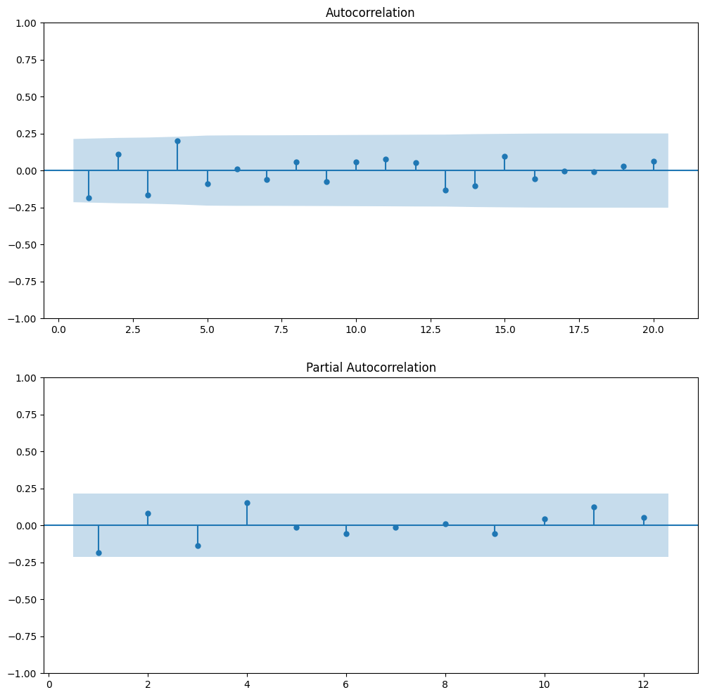

```python
# Plot ACF and PACF for residuals

fig, (ax1, ax2) = plt.subplots(2, 1, figsize=(12, 12))
plot_acf(residuals, ax=ax1, zero=False)
plot_pacf(residuals, ax=ax2, zero=False, lags=12)
plt.show()
```

- After reviewing the ACF and PACF for the resiuals from this model and noticing that the Ljung Box test (below) indicates that the residuals are white noise, p-value = 0.34 >0.05, this seems to be a reasonable model for the data.

```python
#execute the Ljung Box test on the residuals

sm.stats.acorr_ljungbox(residuals, lags=[12], return_df=True)
```

|  | lb_stat | lb_pvalue |
| --- | --- | --- |
| 12 | 13.317533 | 0.34639 |

Convert predictions into a data frame in order to compute the forecast error

```python
# convert to data frame
predicted_mean = pred_units.predicted_mean
conf_int = pred_units.conf_int()

prediction_df = pd.DataFrame({
    'predicted_mean': predicted_mean,
    'lower_bound': conf_int.iloc[:, 0],
    'upper_bound': conf_int.iloc[:, 1]
})
prediction_df = prediction_df.tail(-1)
prediction_df.head()
```

| Date | predicted_mean | lower_bound | upper_bound |
| --- | --- | --- | --- |
| 2004-02-01 | 953.358230 | -1271.349768 | 3178.066228 |
| 2004-03-01 | 383.566142 | -1835.050611 | 2602.182895 |
| 2004-04-01 | 328.019849 | -1890.520537 | 2546.560235 |
| 2004-05-01 | 180.628518 | -2037.910907 | 2399.167943 |
| 2004-06-01 | 599.108976 | -1619.430436 | 2817.648389 |

Join actual values to predicted values

```python
# add back actuals --
prediction_df = pd.concat([prediction_df,bag_ts.to_frame(name='Cancelled')],axis=1)
prediction_df = prediction_df.tail(-1)
prediction_df.head()
```

| Date | predicted_mean | lower_bound | upper_bound | Cancelled |
| --- | --- | --- | --- | --- |
| 2004-02-01 | 953.358230 | -1271.349768 | 3178.066228 | 312 |
| 2004-03-01 | 383.566142 | -1835.050611 | 2602.182895 | 321 |
| 2004-04-01 | 328.019849 | -1890.520537 | 2546.560235 | 162 |
| 2004-05-01 | 180.628518 | -2037.910907 | 2399.167943 | 652 |
| 2004-06-01 | 599.108976 | -1619.430436 | 2817.648389 | 549 |

Calculate the Forecast Error

```python
# calc error
errors = prediction_df['Cancelled'] - prediction_df['predicted_mean']
# absolue value of error
errors_abs = errors.abs()
# -- mape --
mape = (errors_abs/prediction_df['Cancelled'].abs()).mean()
# -- rmse
rmse = (errors**2).mean()**0.5
# -- print it out
print(f'MAPE = {mape:.3%}')
print(f'RMSE = {rmse:,.3f}')
```

```
MAPE = 46.380%
RMSE = 361.895
```

```python
# Generate forecast for the next six months
forecast = fit_AR1.get_forecast(steps=6)
mean_forecast = forecast.predicted_mean
confidence_intervals = forecast.conf_int()

# Create a DataFrame with forecasted values and confidence intervals
forecast_df = pd.DataFrame({
    'Forecasted_CPI': mean_forecast,
    'Lower_Bound': confidence_intervals.iloc[:, 0],
    'Upper_Bound': confidence_intervals.iloc[:, 1]
})

forecast_df
```

|  | Forecasted_CPI | Lower_Bound | Upper_Bound |
| --- | --- | --- | --- |
| 2011-01-01 | 430.073537 | -272.558477 | 1132.705552 |
| 2011-02-01 | 754.502650 | 33.546969 | 1475.458330 |
| 2011-03-01 | 305.921480 | -432.885259 | 1044.728219 |
| 2011-04-01 | 137.778140 | -618.456895 | 894.013175 |
| 2011-05-01 | 88.436118 | -684.834385 | 861.706620 |
| 2011-06-01 | 317.500803 | -472.437864 | 1107.439469 |

Plot the series and append the six month forecast. Notice that the forecast follows a pattern similar to the one observed in the actual data

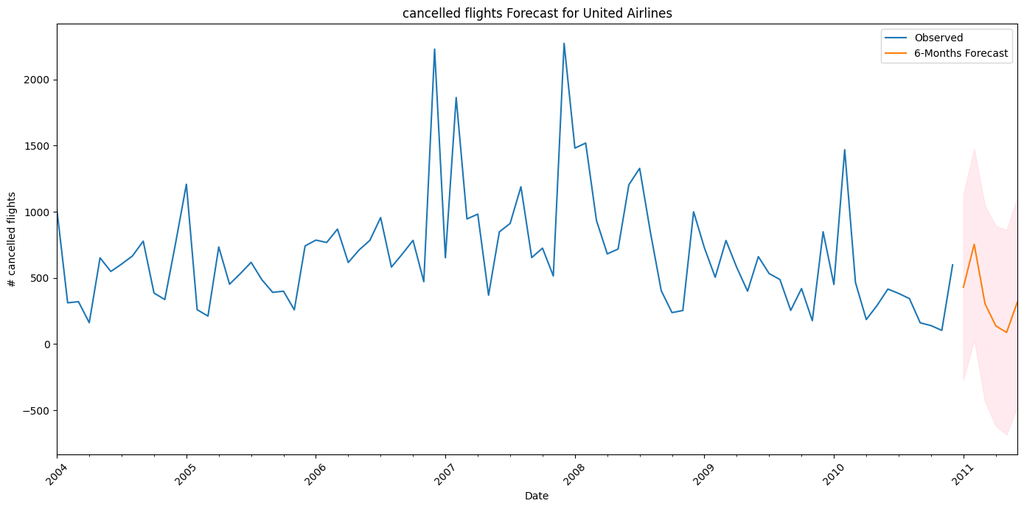

```python
# Plot forecast
plt.figure(figsize=(14, 7))
bag_ts.plot(label='Observed', legend=True)
mean_forecast.plot(label='6-Months Forecast', legend=True)
plt.fill_between(confidence_intervals.index,
                 confidence_intervals.iloc[:, 0],
                 confidence_intervals.iloc[:, 1], color='pink', alpha=0.3)
plt.title("cancelled flights Forecast for United Airlines")
plt.xlabel("Date")
plt.ylabel("# cancelled flights")
plt.xticks(rotation=45)
plt.tight_layout()
plt.legend()
plt.show()
```

# Baggage claims for American Eagle Airlines

```python
# Load Data

data_path = '/content/drive/My Drive/Data/Eagle.csv'

bag_dat = pd.read_csv(data_path)

bag_dat.head
bag_dat.info()
print(bag_dat)
```

```
<class 'pandas.core.frame.DataFrame'>
RangeIndex: 84 entries, 0 to 83
Data columns (total 8 columns):
 #   Column     Non-Null Count  Dtype
---  ------     --------------  -----
 0   Airline    84 non-null     object
 1   Date       84 non-null     object
 2   Month      84 non-null     int64
 3   Year       84 non-null     int64
 4   Baggage    84 non-null     int64
 5   Scheduled  84 non-null     int64
 6   Cancelled  84 non-null     int64
 7   Enplaned   84 non-null     int64
dtypes: int64(6), object(2)
memory usage: 5.4+ KB
           Airline    Date  Month  Year  Baggage  Scheduled  Cancelled  \
0   American Eagle  Jan-04      1  2004    12502      38276       2481
1   American Eagle  Feb-04      2  2004     8977      35762        886
2   American Eagle  Mar-04      3  2004    10289      39445       1346
3   American Eagle  Apr-04      4  2004     8095      38982        755
4   American Eagle  May-04      5  2004    10618      40422       2206
..             ...     ...    ...   ...      ...        ...        ...
79  American Eagle  Aug-10      8  2010     9583      37697        538
80  American Eagle  Sep-10      9  2010     8324      36524        630
81  American Eagle  Oct-10     10  2010     8498      37766        542
82  American Eagle  Nov-10     11  2010     8067      35778        335
83  American Eagle  Dec-10     12  2010    11526      36605       2004

    Enplaned
0     992360
1    1060618
2    1227469
3    1234451
4    1267581
..       ...
79   1388344
80   1336997
81   1462312
82   1346419
83   1298950

[84 rows x 8 columns]
```

## 4. Examine the correlation between the number of baggage claims and the number of canceled flights, passengers enplaned, and flights scheduled.

- There is a moderate positive correlation (Correlation: 0.62) between the number of canceled flights and the number of baggage claims. This suggests that when airlines experience more flight cancellations, there is a tendency for an increase in baggage claims. Possible explanations could include disruptions in travel plans leading to mishandled baggage or re-routing of luggage causing delays and issues.
- The correlation between baggage claims and Scheduled Flights (Correlation: 0.78): A correlation of 0.78 signifies a strong positive relationship. The positive sign indicates that as the number of scheduled flights increases, the number of baggage claims also tends to increase. During periods of highly scheduled flights (such as holiday seasons or peak travel times), there is likely to be a corresponding increase in baggage claims.
- The correlation between baggage claims and Enplaned Passengers (Correlation: 0.61):A moderate positive relationship. The positive sign indicates that as the number of enplaned passengers increases, the number of baggage claims also tends to increase.Airlines with higher passenger numbers might experience a proportional increase in both enplaned passengers and baggage claims.

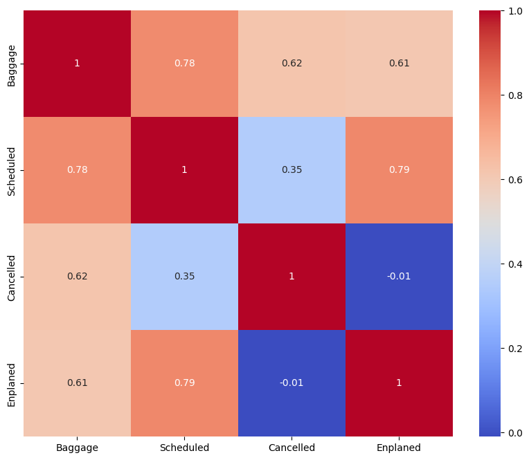

```python
bag_dat_sub = bag_dat.drop(columns=['Airline', 'Date', 'Month', 'Year'])


# Compute correlations
cormat = bag_dat_sub.corr()

# Round correlation matrix to 2 decimal places
cormat = cormat.round(2)

# Plot correlation matrix using a heatmap
plt.figure(figsize = (10,8))
sns.heatmap(cormat,annot=True, cmap = 'coolwarm')
plt.show()
```

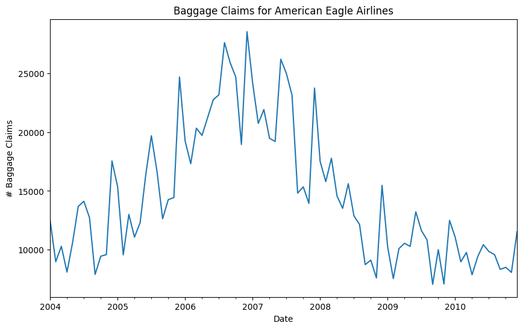

```python
# Convert date column to a date class variable

# Create a monthly index for the series
bag_dat['Date'] = pd.to_datetime(bag_dat['Date'], format="%b-%y")
bag_ts = pd.Series(bag_dat['Baggage'].values, index=bag_dat['Date'])

bag_ts.index.freq = 'MS'


#Plot the series
plt.figure(figsize=(10, 6))
bag_ts.plot()
plt.title("Baggage Claims for American Eagle Airlines")
plt.xlabel("Date")
plt.ylabel("# Baggage Claims")
plt.show()
```